# STAT5003 - Project Plan and EDA

Group W06_G08

Team SIDs: 540771859, 510214539, 510027847, 500135499, 500477735

## Problem Definition

In New South Wales, traffic accidents have long posed a serious public safety concern, resulting in substantial human casualties and imposing significant economic burden. Despite substantial government investment in road safety (e.g., a commitment of $2.8 billion over the next 4 years), accidents continue to occur, often with varying and unpredictable outcomes [1]. Furthermore, Sydney is experiencing an increasing risk of accidents due to rapid population growth, complex road systems and heavy traffic. Although reducing the likelihood of accidents is a topic of intense research, we propose that investigating factors contributing to the severity of these accidents could provide a different angle for insight into effective methods to minimise harm on the road.

In order to achieve this, this study aims to explore whether it is possible to predict accident severity by building a model using existing accident data and enforcement information. This research, framed as a multi-class classification problem, has the objective of categorising accidents into five distinct levels: “fatal”, “serious injury”, “moderate injury”, “minor injury”, or “no injury”. By analysing factors including the time and date of accidents, weather conditions, road type, vehicle involvement and distance from traffic enforcement cameras, this study expects to uncover patterns in the factors influencing accident outcomes.

The study’s specific objectives are threefold:

1. To explore the relationship between accident factors and accident severity.
2. To assess the role of vehicle type and involvement pattern (who collided first, how many vehicles involved) in predicting severity.
3. To evaluate the impact of speed enforcement efforts on accident outcomes.

Improving the ability to predict accident severity not only enhances public safety but also supports evidence-based policymaking in Sydney and Australia more broadly. The insights from this research will help authorities design more targeted safety interventions, strategically place enforcement cameras, and allocate resources efficiently, minimising harm and enhancing the overall safety of the transport system.

## Data Description

To analyse how different factors can affect the severity of injury from vehicular accident in NSW, two datasets were pulled from the NSW Government’s Transport Open Data Hub. The first dataset, `nsw_road_crash_data_2019–2023_crash.xlsx` [2], provides the primary features for analysis, including the outcome variable `Degree of Crash – Detailed`, which categorises crash severity into five increasing levels: Non-casualty (towaway), Minor/Other Injury, Moderate Injury, Serious Injury, and Fatal.

This dataset comprises 93,492 rows and 50 features, capturing both categorical and numerical information. A preview of the first row and associated feature types is presented below.

```r
# Import Crash-level data
crash_2019_2023 <- read_excel("nsw_road_crash_data_2019-2023_crash.xlsx")

# Import Speed and red-light camera data
fixed_cameras <- read_excel("nsw-speed-cameras-gps-locations-november-2021.xlsx", sheet = 1)
redlight_cameras <- read_excel("nsw-speed-cameras-gps-locations-november-2021.xlsx", sheet = 2)
head(crash_2019_2023,1)
```

| Crash ID | Degree of crash | Degree of crash - detailed | Reporting year | Year of crash | Month of crash | Day of week of crash | Two-hour intervals | Street of crash | Street type | Distance | Direction | Identifying feature | Identifying feature type | Town | Route no. | School zone location | School zone active | Type of location | Latitude | Longitude | LGA | Urbanisation | Conurbation 1 | Alignment | Primary permanent feature | Primary temporary feature | Primary hazardous feature | Street lighting | Road surface | … |
| --- | --- | --- | --- | --- | --- | --- | --- | --- | --- | --- | --- | --- | --- | --- | --- | --- | --- | --- | --- | --- | --- | --- | --- | --- | --- | --- | --- | --- | --- | --- |
| 1189190 | Fatal | Fatal | 2019 | 2019 | January | Tuesday | 02:00 - 03:59 | SEXTONVILLE | RD | 370 | East | LAKESIDE | DR | CASINO | NA | No | Not a school zone | 2-way undivided | -28.8591 | 153.0184 | Richmond Valley | Country urban | Rest of NSW - Urban | Curved | NA | NA | NA | On | Sealed | … |

The second dataset analysed in this study is `nsw-speed-cameras-gps-locations-november-2021.xlsx` [3]. This file contains two sheets: the locations of fixed speed cameras across NSW as of November 2021, and the locations of red-light speed cameras. The fixed speed camera sheet contains 8 variables and covers 103 distinct roads, while the red-light camera sheet contains 10 variables and covers 201 roads. Multiple cameras may be installed along the same road, with some red-light sites hosting up to three cameras, each identified by their corresponding latitude (Lat) and longitude (Long) coordinates. Previews of the two sheets are presented below.

```r
head(fixed_cameras,1)
```

| SZ? | SUBURB/TOWN | ROAD/S | Cameras | Lat(1) | Long(1) | Lat(2) | Long(2) |
| --- | --- | --- | --- | --- | --- | --- | --- |
| Y | Ashfield | Hume Highway, between Murrell Street and Queen Street (school zone) | 1 | -33.89018 | 151.128 | NA | NA |

```r
head(redlight_cameras,1)
```

| SZ? | SUBURB/TOWN | ROAD/S | Cameras | Lat(1) | Long(1) | Lat(2) | Long(2) | Lat(3) | Long(3) |
| --- | --- | --- | --- | --- | --- | --- | --- | --- | --- |
| N | Kotara / Adamstown | Park Avenue and Northcott Drive | 1 | -32.940334999999997 | 151.712118 | NA | NA | NA | NA |

Collectively, the crash and camera datasets provide a comprehensive view of road safety conditions in NSW, enabling analysis of how environmental, temporal, and enforcement-related factors interact to influence crash severity. While these datasets are rich in detail, they also present challenges such as being large datasets, having a large proportion of categorical variables, missing values in environmental and location fields, having class imbalances in crash severity outcomes, and requiring substantial work for integration. Addressing these issues is essential to ensure reliable insights that can support more targeted and effective road-safety interventions.

## Data Cleaning and Preparation

Before performing exploratory data analysis and fitting models, both datasets required cleaning and preparation to ensure consistency, accuracy and usability. The speed camera data sheets were combined, and the Lat(1) and Long(1) features were defined as for merging. Next, new columns were added into each dataset to define them as ‘Fixed’ and ‘Red-Light’, while also adding an additional 2 rows in to the fixed cameras dataset to represent Lat(3) and Long(3) (filled with empty values). `Bind_rows` was then used to combine the 2 datasets into a new dataframe denoted ‘speed cameras’.

```r
# Combine the camera datasets together into 1 dataframe
# Columns to standardise
latlong_cols <- c("Lat(1)", "Long(1)", "Lat(2)", "Long(2)", "Lat(3)", "Long(3)")

# redlight cameras start with more columns than fixed cameras
redlight_cameras <- redlight_cameras %>%
  mutate(Camera_type = "Red_Light") %>%
  # Force all Lat/Long columns to numeric
  mutate(across(all_of(latlong_cols), ~ parse_number(as.character(.))))

# Add the missing columns as numeric NAs, then set Camera_type
fixed_cameras <- fixed_cameras %>%
  mutate(
    `Lat(2)`  = NA_real_,
    `Long(2)` = NA_real_,
    `Lat(3)`  = NA_real_,
    `Long(3)` = NA_real_,
    Camera_type = "Fixed"
  ) %>%
  # Ensure all Lat/Long columns exist and are numeric
  mutate(across(all_of(latlong_cols), ~ parse_number(as.character(.))))

# Enforce a consistent column order for ease of use
col_order <- c("SZ?", "SUBURB/TOWN", "ROAD/S", "Cameras",
               "Lat(1)", "Long(1)", "Lat(2)", "Long(2)", "Lat(3)", "Long(3)",
               "Camera_type")

# Bind cameras into one dataset
speed_cameras <- bind_rows(
  redlight_cameras %>% select(any_of(col_order)),
  fixed_cameras %>% select(any_of(col_order))
)

# head(speed_cameras)
```

The camera placement in `speed_cameras` has cameras from pre-November 2019, but no time of installation. As such, we opted to remove any crashes from prior to November 2019, as we could not guarantee whether a camera existed prior to then. This is a potential limitation to the study, as cameras that were installed post this data collection are not included, which could lead to bias in the data.

```r
# Keep only crashes from Nov 2019 onwards
crash_2019_2023_filtered <- crash_2019_2023 %>%
  filter(`Year of crash` > 2019 |
           (`Year of crash` == 2019 & `Month of crash` %in% c("November", "December")))
```

We then calculated the distances between the nearest speed cameras of each type and populate the data into the `crash_2019_2023_filtered` dataset. The speed_camera dataset was first restructured so that sites with multiple latitude–longitude coordinate pairs were split into individual rows, ensuring that each camera was represented as a distinct observation. The coordinates were then converted into spatial objects using the WGS84 reference system (standard GPS format) and ‘sf’ library. A similar process was applied to the crash dataset, filtering out rows without valid geographic coordinates. The camera data was further divided into fixed and red-light subsets, and spatial distance calculations were performed to identify the nearest enforcement camera for each crash location. Finally, the calculated distances (in kilometers) to the closest fixed and red-light camera were added back as new variables in the crash dataset.

```r
# Splits cameras with multiple points to individual rows
speed_cam_pts <- speed_cameras %>%
  pivot_longer(
    cols = c(`Lat(1)`, `Long(1)`, `Lat(2)`, `Long(2)`, `Lat(3)`, `Long(3)`),
    names_to = c(".value", "idx"),
    names_pattern = "(Lat|Long)\\((\\d)\\)"
  ) %>%
  filter(!is.na(Lat), !is.na(Long)) %>%
  mutate(Lat = as.numeric(Lat), Long = as.numeric(Long)) %>%
  distinct(Long, Lat, Camera_type, .keep_all = TRUE)  # keep type for splitting

#Applies spatial library to convert coordinates spatial objects
#crs = 4326 sets the coordinate reference system to WGS84 (standard GPS lat/long)
speed_cam_sf <- st_as_sf(speed_cam_pts, coords = c("Long", "Lat"), crs = 4326)
sf::sf_use_s2(TRUE)

crash_df <- crash_2019_2023_filtered
valid_rows <- which(!is.na(crash_df$Longitude) & !is.na(crash_df$Latitude))
invalid_rows <- which(is.na(crash_df$Longitude) | is.na(crash_df$Latitude)) # Not used other than to confirm that no invalid rows exist

crash_sf <- st_as_sf(
  crash_df[valid_rows, ],
  coords = c("Longitude", "Latitude"),
  crs = 4326
)

# Split cameras by type
fixed_sf     <- speed_cam_sf %>% filter(Camera_type == "Fixed")
redlight_sf  <- speed_cam_sf %>% filter(Camera_type == "Red_Light")

# Helper to compute nearest distance (km) to a given camera set, returning a vector
nearest_km_to <- function(crash_pts, cam_pts) {
  if (nrow(cam_pts) == 0) return(rep(NA_real_, nrow(crash_pts)))
  nn_idx <- st_nearest_feature(crash_pts, cam_pts)
  as.numeric(st_distance(crash_pts, cam_pts[nn_idx, ], by_element = TRUE)) / 1000
}

# Distances
nearest_fixed_km    <- nearest_km_to(crash_sf, fixed_sf)
nearest_redlight_km <- nearest_km_to(crash_sf, redlight_sf)

# Write back to the full crash dataframe
crash_df$nearest_fixed_km    <- NA_real_
crash_df$nearest_redlight_km <- NA_real_

crash_df$nearest_fixed_km[valid_rows]    <- nearest_fixed_km
crash_df$nearest_redlight_km[valid_rows] <- nearest_redlight_km

crash_2019_2023_filtered <- crash_df

# head(crash_2019_2023_filtered)
```

To prepare the crash dataset for analysis, the `speed_limit` variable was cleaned by removing the “km/h” text, trimming white spaces, and converting the field into a numeric type suitable for quantitative analysis. Redundant columns such as `Degree of crash`, `Reporting year`, and `Street of crash`, etc., were dropped to reduce noise and focus on relevant features for modelling.

A summary of missing counts and percentages was generated for all variables, highlighting that `Primary permanent feature`, `Primary temporary feature`, `Primary hazardous feature`, and `DCA supplement` have proportions of 73.75%, 98.56%, 97.88%, and 86.62% values missing respectively. The large proportion of missing values in these features suggests that they will not be effective in predicting the degree of crash, so they were removed from the feature set.

At this stage, no rows were removed on the basis of missing data; instead, these gaps were retained for further consideration during exploratory data analysis. The table describing features with missing data is available in the appendix.

```r
#Remove km/h from Speed limit
crash_data <- crash_2019_2023_filtered %>%
  mutate(
    # remove km/h
    `Speed limit` = gsub("(?i)\\s*km/h", "", `Speed limit`, perl = TRUE),
    # trim spaces
    `Speed limit` = trimws(`Speed limit`),
    # convert to numeric
    `Speed limit` = as.numeric(`Speed limit`)
  )
```

```r
# Drop non-analysed columns before EDA
crash_data <- crash_data %>%
  select(
    -`Degree of crash`,
    -`Reporting year`,
    -`Street of crash`,
    -`Primary permanent feature`,
    -`Primary temporary feature`,
    -`Primary hazardous feature`,
    -`Road classification (admin)`,
    -`Distance`,
    -`Direction`,
    -`Identifying feature`,
    -`Identifying feature type`
  )
```

## Exploratory Data Analysis (EDA)

EDA was conducted on both numerical and categorical features relevant to the research problem. Missing values were discussed previously, with variables missing >70% of data excluded from this section. The missing data for `Other TU type` reflects crashes where it is not applicable, and the data for `Speed limit` is missing completely at random. Graphs and tables have been provided for completeness, accessible via the “*Click to expand tables/plots*” button.

### Numeric Data

There are 16 numerical variables in our final dataset. However, `Crash ID` acts as a unique identifier and so is unrelated to analysis, while the codes for Road User Movement (RUM) and Definition for Coding Accidents (DCA) are discrete numerical values mapping to categorical data, so are explored in the categorical section. Latitude and Longitude describe the relevant latitude and longitude of the crash location. These are useful for calculating distances but are otherwise irrelevant. The remaining 11 variables are explored below.

```r
table(crash_data$`Year of crash`) # Table allows the result to be collapsed.
```

```
##
##  2019  2020  2021  2022  2023
##  3132 18764 17413 18255 18633
```

Route number identifies the road the crash occurred at, or the lower numbered road in the case of a crash at an intersection. This is converted to a categorical variable as per the Classified Roads Schedule [4]. There were 28575 values for Route no. missing at random, making up 37.5% of the data. Crashes were most common on main roads.

```r
crash_data <- crash_data %>%
  mutate(RouteCategory = case_when(
    `Route no.` >= 1    & `Route no.` <= 31    ~ "HW", # Highway
    `Route no.` >= 51   & `Route no.` <= 707   ~ "MR", # Main Road
    `Route no.` >= 2001 & `Route no.` <= 2126  ~ "SR", # Secondary Road
    `Route no.` >= 4000 & `Route no.` <= 4058  ~ "TO", # Tourist Road
    `Route no.` >= 8001 & `Route no.` <= 8011  ~ "TW", # Transitway
    `Route no.` >= 7000 & `Route no.` < 8000   ~ "UR", # Unclassified Regional Road
    `Route no.` >= 6000 & `Route no.` < 6093   ~ "MW", # Sydney Freeway / Motorway / Tollway not otherwise declared
    is.na(`Route no.`)   ~ NA,
    TRUE ~ "Other"   # catch anything outside defined ranges
  )) %>%
    mutate(RouteCategory = factor(RouteCategory,
                                levels = c("HW","MR","SR","TO","MW","UR","TW"),
                                ordered = TRUE))

crash_data$RouteCategory %>% table()
## .
##    HW    MR    SR    TO    MW    UR    TW
## 13319 22973  1725    48  2703  6840    14
```

The speed limit has 11 possible values, from 10 to 110 km/h in increments of 10. As previously seen, there are also 24 values missing completely at random, making up just 0.03% of the data. Crashes are recorded most frequently at 50-60km/h, likely due to these being the most common urban speed limits. However, proportionately more fatal crashes appear to occur on roads with speed limits above 80 km/h. This also appears to be the case at lower speeds of 10-20 km/h, although the lack of data here makes this extremely variable.

**Click to expand tables/plots**

```r
# library(scales)  # for percent_format()

# crash_data %>%
#   filter(!is.na(`Speed limit`), !is.na(`Degree of crash - detailed`)) %>%
#   ggplot(aes(x = factor(`Speed limit`), fill = `Degree of crash - detailed`)) +
#     geom_bar(position = "fill") +
#     labs(
#       x = "Speed Limit (km/h)",
#       y = "Proportion of Crashes",
#       title = "Proportion of Crashes by Speed Limit and Degree of Crash",
#       fill = "Degree of Crash"
#     ) +
#     scale_fill_brewer(palette = 'RdYlGn',direction = -1) +
#     scale_y_continuous(labels = percent_format()) +
#     theme_minimal()

tab <- table(crash_data$`Degree of crash - detailed`,crash_data$`Speed limit`) %>% addmargins()
rownames(tab)[nrow(tab)] <- "Total"
colnames(tab)[ncol(tab)] <- "Total"
kable(tab, format = "html", booktabs = TRUE, caption = "Crashes by Speed Limit and Severity") %>%
  add_header_above(c(" " = 1, "Speed Limit" = ncol(tab)-1, " " = 1)) %>%
  kable_styling(full_width = FALSE, position = "center", bootstrap_options = c("striped", "hover", "condensed", "responsive"))
```

Crashes by Speed Limit and Severity

|  | Speed Limit 10 | Speed Limit 20 | Speed Limit 30 | Speed Limit 40 | Speed Limit 50 | Speed Limit 60 | Speed Limit 70 | Speed Limit 80 | Speed Limit 90 | Speed Limit 100 | Speed Limit 110 | Total |
| --- | --- | --- | --- | --- | --- | --- | --- | --- | --- | --- | --- | --- |
| Non-casualty (towaway) | 11 | 8 | 21 | 840 | 9273 | 6537 | 1953 | 1935 | 318 | 2603 | 1248 | 24747 |
| Minor/Other Injury | 10 | 4 | 50 | 696 | 4026 | 4233 | 1451 | 1141 | 173 | 1040 | 390 | 13214 |
| Moderate Injury | 18 | 11 | 41 | 948 | 7136 | 5900 | 1696 | 2219 | 290 | 2455 | 754 | 21468 |
| Serious Injury | 18 | 9 | 39 | 635 | 4767 | 4082 | 1189 | 1911 | 217 | 2062 | 673 | 15602 |
| Fatal | 1 | 1 | 0 | 23 | 203 | 185 | 79 | 167 | 17 | 378 | 88 | 1142 |
| Total | 58 | 33 | 151 | 3142 | 25405 | 20937 | 6368 | 7373 | 1015 | 8538 | 3153 | 76173 |

Number of traffic units (TU) involved refers to the number of vehicles and pedestrians involved in the crash. This is most often 1 or 2 TUs, but with a maximum of 26. This is a discrete numerical variable.

```r
table(crash_data$`No. of traffic units involved`)
```

```
##
##     1     2     3     4     5     6     7     8     9    10    11    16    18
## 22733 44937  6618  1439   309    89    34    16     7     7     2     2     1
##    21    26
##     2     1
```

Number killed refers to the number of people who died within 30 days of the crash. Similarly, number seriously injured refers to the number of people who were admitted to hospital because of the crash, but did not die. Number moderately injured refers to the number of people who attended the emergency department but were not admitted to hospital, while number minor/other injured are the number of people who had an injury recorded but did not meet any previous requirements. All are discrete numerical variables, and all are extremely positive-skewed distributions, seen below.

```r
# Printing summaries so they get folded
summary(crash_data$`No. killed`)
```

```
##     Min.  1st Qu.   Median     Mean  3rd Qu.     Max.
##  0.00000  0.00000  0.00000  0.01622  0.00000 10.00000
```

```r
summary(crash_data$`No. seriously injured`)
```

```
##    Min. 1st Qu.  Median    Mean 3rd Qu.    Max.
##  0.0000  0.0000  0.0000  0.2277  0.0000 11.0000
```

```r
summary(crash_data$`No. moderately injured`)
```

```
##    Min. 1st Qu.  Median    Mean 3rd Qu.    Max.
##  0.0000  0.0000  0.0000  0.3656  1.0000 10.0000
```

```r
summary(crash_data$`No. minor-other injured`)
```

```
##    Min. 1st Qu.  Median    Mean 3rd Qu.    Max.
##  0.0000  0.0000  0.0000  0.2349  0.0000 48.0000
```

`nearest_fixed_km` and `nearest_redlight_km` are two continuous variables referring to the distance from the crash to the nearest fixed or red-light speed camera. These range from 0.0071 km and 0 km to 979 km and 934 km for the fixed and red-light cameras respectively. The median is 4.5 km for fixed cameras and 3.1 km for red-light cameras, but the means for both are over 30 km, indicating significant skew in the distributions. There is an extremely high correlation ($r=0.83$) between these two variables, suggesting multicollinearity, seen in the scatter plot.

**Click to expand tables/plots**

```r
# Convert summaries to numeric vectors
fixed_summary <- summary(crash_data$`nearest_fixed_km`)
redlight_summary <- summary(crash_data$`nearest_redlight_km`)

# Combine into a data frame
summary_table <- rbind(
  `Nearest Fixed Camera (km)`    = fixed_summary,
  `Nearest Redlight Camera (km)` = redlight_summary
)

# Convert to data frame for nicer printing
summary_table <- as.data.frame(summary_table)

# Print nicely
kable(summary_table, format = "html", booktabs = TRUE,
      caption = "Summary Statistics of Distances") %>%
  kable_styling(full_width = FALSE, position = "center", bootstrap_options = c("striped", "hover", "condensed", "responsive"))
```

Summary Statistics of Distances

|  | Min. | 1st Qu. | Median | Mean | 3rd Qu. | Max. |
| --- | --- | --- | --- | --- | --- | --- |
| Nearest Fixed Camera (km) | 0.0070701 | 1.932705 | 4.546221 | 33.87956 | 20.17476 | 979.0112 |
| Nearest Redlight Camera (km) | 0.0000482 | 1.038575 | 3.148522 | 36.12065 | 37.85374 | 933.5724 |

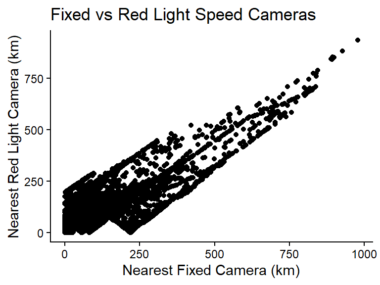

```r
crash_data %>% ggplot(aes(x = nearest_fixed_km, y = nearest_redlight_km)) +
  geom_point() +
  labs(title = "Fixed vs Red Light Speed Cameras",x = "Nearest Fixed Camera (km)", y = "Nearest Red Light Camera (km)") +
  theme_classic()
```

### Categorical Data

This section presents an exploratory data analysis of the categorical features within the crash dataset, with a specific focus on understanding their distributions and their relationships with the target variable `Degree of crash – detailed`.

For clarity and coherence, categorical variables have been analysed by thematic groups:

1. Time-related variables: Month, time and day of week of crash, as well as school zone location and whether the school zone was active.
2. Weather and environmental conditions: Weather, street lighting and natural lighting.
3. Road type: Street type, type of location, urbanisation, alignment, road surface and surface condition.
4. Traffic controls: Signal operation and other traffic control.
5. Traffic unit (TU) and vehicle involvement: Road User Movement (RUM), Definition for Coding Accidents (DCA), Key TU type and (if applicable) other TU type.

The distribution of the target variable is provided in the below table.

```r
style_column(crash_data$`Degree of crash - detailed`,"Degree of Crash")
```

| Degree of Crash | Non-casualty (towaway) | Minor/Other Injury | Moderate Injury | Serious Injury | Fatal | Total |
| --- | --- | --- | --- | --- | --- | --- |
| Crash Frequency | 24755 | 13219 | 21474 | 15607 | 1142 | 76197 |

We now explore each categorical feature and their relationship to the target variable.

#### Time-relevant features

School zone also affects crash severity, with less than 2% of all incidents occurring in active school zones. These tend to involve non-fatal injuries, likely due to reduced speeds but increased pedestrian vulnerability.

**Click to expand tables/plots**

```r
style_column(crash_data_cat$`Month of crash`,"Month of Crash")
```

| Month of Crash | January | February | March | April | May | June | July | August | September | October | November | December | Total |
| --- | --- | --- | --- | --- | --- | --- | --- | --- | --- | --- | --- | --- | --- |
| Crash Frequency | 5536 | 6000 | 6547 | 5613 | 6687 | 6405 | 5978 | 5803 | 5702 | 6141 | 7990 | 7795 | 76197 |

```r
style_column(crash_data_cat$`Day of week of crash`,"Day of Week of Crash")
```

| Day of Week of Crash | Monday | Tuesday | Wednesday | Thursday | Friday | Saturday | Sunday | Total |
| --- | --- | --- | --- | --- | --- | --- | --- | --- |
| Crash Frequency | 10040 | 10491 | 11183 | 11388 | 12131 | 11352 | 9612 | 76197 |

```r
style_column(crash_data_cat$`Two-hour intervals`,"Two-Hour Intervals")
```

| Two-Hour Intervals | 00:01 - 01:59 | 02:00 - 03:59 | 04:00 - 05:59 | 06:00 - 07:59 | 08:00 - 09:59 | 10:00 - 11:59 | 12:00 - 13:59 | 14:00 - 15:59 | 16:00 - 17:59 | 18:00 - 19:59 | 20:00 - 21:59 | 22:00 - Midnight | Unknown | Total |
| --- | --- | --- | --- | --- | --- | --- | --- | --- | --- | --- | --- | --- | --- | --- |
| Crash Frequency | 2531 | 1882 | 2608 | 5896 | 7759 | 8123 | 8882 | 10659 | 11082 | 7469 | 5193 | 4109 | 4 | 76197 |

```r
crash_data_cat <- crash_data_cat %>%
  mutate(
    `School zone` = ifelse(
      `School zone active` == "Yes",
      "Yes", "No"
    )
  )
table(crash_data_cat$`School zone`,crash_data_cat$`Degree of crash - detailed`) %>%
  kable(format = "html", booktabs = TRUE,
      caption = "Crash Severity in Active School Zone") %>%
  kable_styling(full_width = FALSE, position = "center")
```

Crash Severity in Active School Zone

|  | Non-casualty (towaway) | Minor/Other Injury | Moderate Injury | Serious Injury | Fatal |
| --- | --- | --- | --- | --- | --- |
| No | 24577 | 13063 | 21296 | 15480 | 1140 |
| Yes | 178 | 156 | 178 | 127 | 2 |

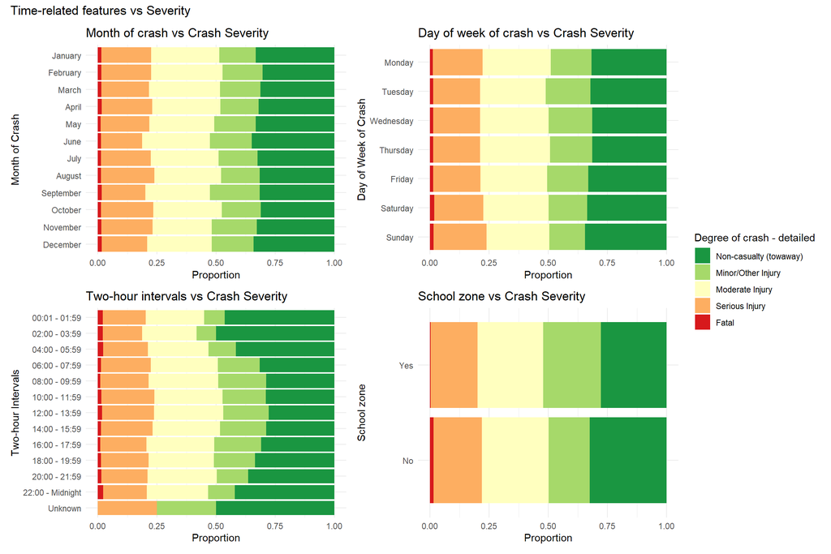

```r
# Month vs target
p_month_of_crash <- ggplot(crash_data_cat, aes(x = forcats::fct_rev(`Month of crash`), fill = `Degree of crash - detailed`)) +
  geom_bar(position = "fill") +
  labs(title = "Month of crash vs Crash Severity", x = "Month of Crash",
       y = "Proportion") +
  theme_minimal() +
  scale_fill_brewer(palette = 'RdYlGn',direction = -1) +
  coord_flip()

# Day of week vs target
p_day_of_week <- ggplot(crash_data_cat, aes(x = forcats::fct_rev(`Day of week of crash`), fill = `Degree of crash - detailed`)) +
  geom_bar(position = "fill") +
  labs(title = "Day of week of crash vs Crash Severity", x = "Day of Week of Crash",
       y = "Proportion") +
  theme_minimal() +
  scale_fill_brewer(palette = 'RdYlGn',direction = -1) +
  coord_flip()

# Time (2h interval) vs target
p_time_two_hour <- ggplot(crash_data_cat, aes(x = forcats::fct_rev(`Two-hour intervals`), fill = `Degree of crash - detailed`)) +
  geom_bar(position = "fill") +
  labs(title = "Two-hour intervals vs Crash Severity", x = "Two-hour Intervals",
       y = "Proportion") +
  theme_minimal() +
  scale_fill_brewer(palette = 'RdYlGn',direction = -1) +
  coord_flip()

# School zone vs Target
p_school_zone <- ggplot(crash_data_cat, aes(x = `School zone`, fill = `Degree of crash - detailed`)) +
  geom_bar(position = "fill") +
  labs(title = "School zone vs Crash Severity",
       y = "Proportion") +
  theme_minimal() +
  scale_fill_brewer(palette = 'RdYlGn',direction = -1) +
  coord_flip()

# plot matrix
time_plots <- list(
  p_month_of_crash,
  p_day_of_week,
  p_time_two_hour,
  p_school_zone
)

p_time_matrix <- wrap_plots(time_plots, ncol = 2) +
  plot_layout(guides = "collect") +
  plot_annotation(title = "Time-related features vs Severity")

p_time_matrix
```

#### Weather & Environment-relevant features

Weather and natural lighting conditions are missing completely at random (MCAR) around 1% of the time, whereas street lighting status is unknown closer to 36% of the time. The majority of crashes happen in fine weather and in daylight. Proportionally, however, crashes during poorer weather conditions and at dawn, dusk and nighttime are more likely to be fatal. Additionally, crashes in areas with no street lighting installed are much more likely to be serious or fatal compared to areas with street lighting. While drivers may adjust their behaviour slightly in adverse conditions, the consequences of errors in poor lighting or weather are more severe.

**Click to expand tables/plots**

```r
# tables
# Weather
style_column(crash_data_cat$`Weather`,"Weather")
```

| Weather | Fine | Overcast | Fog or mist | Raining | Snowing | Other | Unknown | Total |
| --- | --- | --- | --- | --- | --- | --- | --- | --- |
| Crash Frequency | 59941 | 5148 | 530 | 9395 | 83 | 151 | 949 | 76197 |

```r
# Street lighting
style_column(crash_data_cat$`Street lighting`, "Street lighting")
```

| Street lighting | Nil | Off | On | Unknown / not stated | Total |
| --- | --- | --- | --- | --- | --- |
| Crash Frequency | 19582 | 16549 | 12317 | 27749 | 76197 |

```r
# Natural lighting
tab <- table(crash_data_cat$`Natural lighting`,crash_data_cat$`Degree of crash - detailed`) %>% addmargins()
rownames(tab)[nrow(tab)] <- "Total"
colnames(tab)[ncol(tab)] <- "Total"
kable(tab, format = "html", booktabs = TRUE, caption = "Crashes by Natural Lighting and Severity") %>%
  kable_styling(full_width = FALSE, position = "center")
```

Crashes by Natural Lighting and Severity

|  | Non-casualty (towaway) | Minor/Other Injury | Moderate Injury | Serious Injury | Fatal | Total |
| --- | --- | --- | --- | --- | --- | --- |
| Dawn | 963 | 389 | 677 | 526 | 42 | 2597 |
| Daylight | 14314 | 9426 | 14287 | 10630 | 671 | 49328 |
| Dusk | 1433 | 936 | 1277 | 811 | 64 | 4521 |
| Darkness | 7840 | 2386 | 5185 | 3634 | 365 | 19410 |
| Unknown | 205 | 82 | 48 | 6 | 0 | 341 |
| Total | 24755 | 13219 | 21474 | 15607 | 1142 | 76197 |

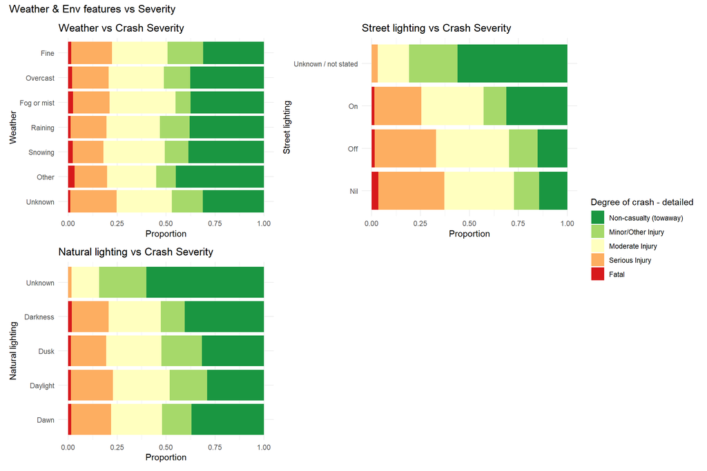

```r
# plots

# Weather vs target
p_weather <- ggplot(crash_data_cat, aes(x = forcats::fct_rev(Weather), fill = `Degree of crash - detailed`)) +
  geom_bar(position = "fill") +
  labs(title = "Weather vs Crash Severity", x = "Weather",
       y = "Proportion") +
  theme_minimal() +
  scale_fill_brewer(palette = 'RdYlGn',direction = -1) +
  coord_flip()

# Street lighting vs target
p_street_lighting <- ggplot(crash_data_cat, aes(x = `Street lighting`, fill = `Degree of crash - detailed`)) +
  geom_bar(position = "fill") +
  labs(title = "Street lighting vs Crash Severity",
       y = "Proportion") +
  theme_minimal() +
  scale_fill_brewer(palette = 'RdYlGn',direction = -1) +
  coord_flip()

# Natural lighting vs target
p_natural_lighting <- ggplot(crash_data_cat, aes(x = `Natural lighting`, fill = `Degree of crash - detailed`)) +
  geom_bar(position = "fill") +
  labs(title = "Natural lighting vs Crash Severity",
       y = "Proportion") +
  theme_minimal() +
  scale_fill_brewer(palette = 'RdYlGn',direction = -1) +
  coord_flip()

# plot matrix
weather_plots <- list(
  p_weather,
  p_street_lighting,
  p_natural_lighting
)

p_weather_matrix <- wrap_plots(weather_plots, ncol = 2) +
  plot_layout(guides = "collect") +
  plot_annotation(title = "Weather & Env features vs Severity")

p_weather_matrix
```

#### Road type-relevant features

Overall, the road type not only influences crash frequency but also affects severity. Rurality, alignment, and surface condition emerge as critical determinants of fatal outcomes, while intersections remain a persistent focal point for injury-producing crashes.

**Click to expand tables/plots**

```r
# tables
# street type
street_table <- crash_data_cat %>%
  count(`Street type`, name = "Frequency") %>%
  arrange(desc(Frequency))

street_table %>%
  kable("html", escape = TRUE, col.names = c("Street type", "Frequency")) %>%
  kable_styling(full_width = TRUE, bootstrap_options = c("striped", "hover", "condensed", "responsive")) %>%
  column_spec(1, width = "12em", extra_css = "word-wrap: break-word; white-space: normal;")
```

| Street type | Frequency |
| --- | --- |
| RD | 29081 |
| ST | 15995 |
| HWY | 13788 |
| DR | 4673 |
| AVE | 3794 |
| EXP | 2802 |
| WAY | 1960 |
| PDE | 1017 |
| LANE | 581 |
| MS | 547 |
| CRES | 493 |
| PL | 298 |
| PKWY | 234 |
| BVD | 157 |
| CCT | 137 |
| TCE | 125 |
| CL | 120 |
| DSTR | 99 |
| BYPA | 86 |
| TRL | 60 |
| CT | 34 |
| ESP | 30 |
| TRK | 17 |
| PROM | 16 |
| GR | 15 |
| SQ | 9 |
| DVWY | 8 |
| ROW | 6 |
| CH | 4 |
| WALK | 4 |
| MALL | 2 |
| MEWS | 2 |
| ACCS | 1 |
| CSWY | 1 |
| GDNS | 1 |

```r
# type of location
style_column(crash_data_cat$`Type of location`,"Type of Location")
```

| Type of Location | 1-way street | 2-way undivided | Divided road | Dual freeway | L-junction | Multiple intersection | Other | Roundabout | Single limited access | T-junction | Unknown | X-intersection | Y-junction | Total |
| --- | --- | --- | --- | --- | --- | --- | --- | --- | --- | --- | --- | --- | --- | --- |
| Crash Frequency | 346 | 29760 | 8875 | 3008 | 187 | 76 | 371 | 4217 | 56 | 17894 | 8 | 11312 | 87 | 76197 |

```r
# urbanisation
style_column(crash_data_cat$`Urbanisation`,"Urbanisation")
```

| Urbanisation | Country non-urban | Country unknown | Country urban | Newcastle met. area | Sydney metro. area | Wollongong met. area | Total |
| --- | --- | --- | --- | --- | --- | --- | --- |
| Crash Frequency | 10279 | 21 | 19837 | 3718 | 39890 | 2452 | 76197 |

```r
# road alignment
style_column(crash_data_cat$`Alignment`,"Road Alignment")
```

| Road Alignment | Curved | Straight | Total |
| --- | --- | --- | --- |
| Crash Frequency | 17554 | 58643 | 76197 |

```r
# road surface type
style_column(crash_data_cat$`Road surface`,"Road Surface Type")
```

| Road Surface Type | Sealed | Unknown | Unsealed | Total |
| --- | --- | --- | --- | --- |
| Crash Frequency | 74194 | 62 | 1941 | 76197 |

```r
# road surface condition
style_column(crash_data_cat$`Surface condition`,"Road Surface Condition")
```

| Road Surface Condition | Dry | Snow or ice | Unknown | Wet | Total |
| --- | --- | --- | --- | --- | --- |
| Crash Frequency | 61796 | 135 | 494 | 13772 | 76197 |

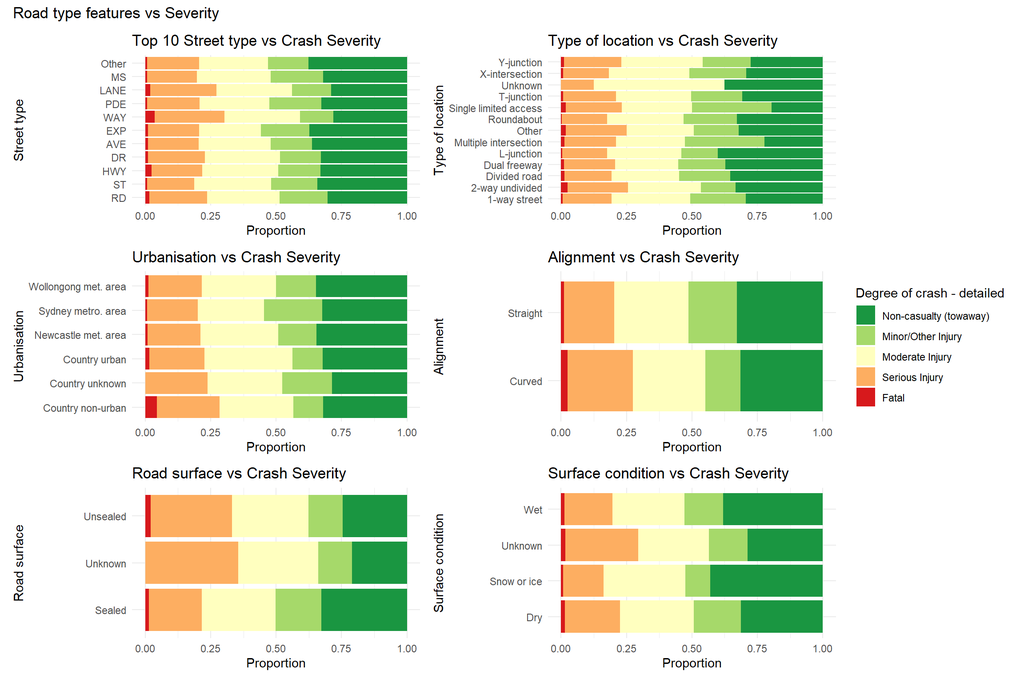

```r
# Keep the top 10 values, group the rest to "Other"
lump_top_n <- function(x, n = 10, other_level = "Other") {
  # Tabulate frequencies
  freq <- sort(table(x), decreasing = TRUE)
  top_levels <- names(freq)[seq_len(min(n, length(freq)))]

  # Replace non-top with "Other"
  x_new <- ifelse(x %in% top_levels, as.character(x), other_level)

  factor(x_new, levels = c(top_levels, other_level))
}

# plots
# Street type vs target
p_street_type <- ggplot(crash_data_cat %>%
         mutate(`Street type` = lump_top_n(`Street type`, n = 10)),
       aes(x = `Street type`, fill = `Degree of crash - detailed`)) +
  geom_bar(position = "fill") +
  labs(title = "Top 10 Street type vs Crash Severity",
       y = "Proportion") +
  theme_minimal() +
  scale_fill_brewer(palette = 'RdYlGn',direction = -1) +
  coord_flip()


# Type of location vs target
p_type_of_location <- ggplot(crash_data_cat, aes(x = `Type of location`, fill = `Degree of crash - detailed`)) +
  geom_bar(position = "fill") +
  labs(title = "Type of location vs Crash Severity",
       y = "Proportion") +
  theme_minimal() +
  scale_fill_brewer(palette = 'RdYlGn',direction = -1) +
  coord_flip()

# Urbanisation vs target
p_urbanisation <- ggplot(crash_data_cat, aes(x = `Urbanisation`, fill = `Degree of crash - detailed`)) +
  geom_bar(position = "fill") +
  labs(title = "Urbanisation vs Crash Severity",
       y = "Proportion") +
  theme_minimal() +
  scale_fill_brewer(palette = 'RdYlGn',direction = -1) +
  coord_flip()

# Alignment vs target
p_alignment <- ggplot(crash_data_cat, aes(x = `Alignment`, fill = `Degree of crash - detailed`)) +
  geom_bar(position = "fill") +
  labs(title = "Alignment vs Crash Severity",
       y = "Proportion") +
  theme_minimal() +
  scale_fill_brewer(palette = 'RdYlGn',direction = -1) +
  coord_flip()

# Road surface vs target
p_surface <- ggplot(crash_data_cat, aes(x = `Road surface`, fill = `Degree of crash - detailed`)) +
  geom_bar(position = "fill") +
  labs(title = "Road surface vs Crash Severity",
       y = "Proportion") +
  theme_minimal() +
  scale_fill_brewer(palette = 'RdYlGn',direction = -1) +
  coord_flip()

# Surface condition vs target
p_surface_condition <- ggplot(crash_data_cat, aes(x = `Surface condition`, fill = `Degree of crash - detailed`)) +
  geom_bar(position = "fill") +
  labs(title = "Surface condition vs Crash Severity",
       y = "Proportion") +
  theme_minimal() +
  scale_fill_brewer(palette = 'RdYlGn',direction = -1) +
  coord_flip()

# plot matrix
road_plots <- list(
  p_street_type,
  p_type_of_location,
  p_urbanisation,
  p_alignment,
  p_surface,
  p_surface_condition
)

p_road_matrix <- wrap_plots(road_plots, ncol = 2) +
  plot_layout(guides = "collect") +
  plot_annotation(title = "Road type features vs Severity")

p_road_matrix
```

#### Traffic control-relevant features

Intersections with traffic signals account for around 15% of total crashes, with the bulk of crashes happening in areas without signals. Crashes are most likely to be severe in areas without traffic signals. Furthermore, although crashes at give way signs are the most frequent type of crash involving other traffic controls, they are relatively unlikely to be severe. Less than 1% of traffic signal or other traffic control data was missing.

**Click to expand tables/plots**

```r
# tables
# Signal operation
style_column(crash_data_cat$`Signals operation`,"Signal Operation")
```

| Signal Operation | Nil | Off | On | Unknown / not stated | Total |
| --- | --- | --- | --- | --- | --- |
| Crash Frequency | 64094 | 383 | 11130 | 590 | 76197 |

```r
# Other traffic control
traffic_control_table <- crash_data_cat %>%
  count(`Other traffic control`, name = "Frequency") %>%
  arrange(desc(Frequency))

traffic_control_table %>%
  kable("html", escape = TRUE, col.names = c("Other traffic control", "Frequency")) %>%
  kable_styling(full_width = TRUE, bootstrap_options = c("striped", "hover", "condensed", "responsive")) %>%
  column_spec(1, width = "12em", extra_css = "word-wrap: break-word; white-space: normal;")
```

| Other traffic control | Frequency |
| --- | --- |
| No traffic controls | 60135 |
| Give way sign | 10484 |
| Stop sign | 2914 |
| Ped crossing | 1857 |
| Other traf. control | 225 |
| No right turn | 224 |
| Left turn only | 120 |
| Road/rail worker | 61 |
| No U turn | 35 |
| Rail X stop sign | 29 |
| Rail X flashing sigs | 28 |
| No entry/wrong way | 27 |
| No left turn | 19 |
| Unknown | 19 |
| Police | 13 |
| Rail X no sign | 4 |
| Left turn on red | 3 |

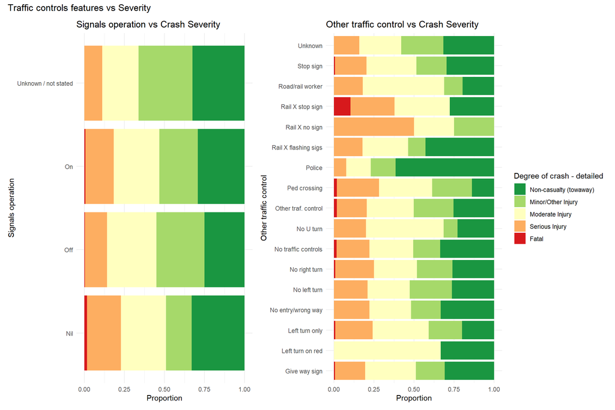

```r
# plots
# Signals operation vs target
p_signals <- ggplot(crash_data_cat, aes(x = `Signals operation`, fill = `Degree of crash - detailed`)) +
  geom_bar(position = "fill") +
  labs(title = "Signals operation vs Crash Severity",
       y = "Proportion") +
  theme_minimal() +
  scale_fill_brewer(palette = 'RdYlGn',direction = -1) +
  coord_flip()

# Other traffic control vs target
p_control <- ggplot(crash_data_cat, aes(x = `Other traffic control`, fill = `Degree of crash - detailed`)) +
  geom_bar(position = "fill") +
  labs(title = "Other traffic control vs Crash Severity",
       y = "Proportion") +
  theme_minimal() +
  scale_fill_brewer(palette = 'RdYlGn',direction = -1) +
  coord_flip()

# plot matrix
controls_plots <- list(
  p_signals,
  p_control
)

p_controls_matrix <- wrap_plots(controls_plots, ncol = 2) +
  plot_layout(guides = "collect") +
  plot_annotation(title = "Traffic controls features vs Severity")

p_controls_matrix
```

#### Traffic unit (TU) involvement-relevant features

Road User Movement (RUM) and Definition for Coding Accidents (DCA) represent the first movement in the crash. Although rear-end collisions are the most common, head-on collisions are more likely to result in a more serious or fatal outcome. The most common first impact types are vehicles hitting another vehicle, but these are unlikely to be fatal unless they are head-on collisions. Less than 1% of any of these features was missing in our dataset.

**Click to expand tables/plots**

```r
# tables
table(crash_data_cat$`RUM - description`)
```

```
##
##       2 left turning      2 right turning             Accident
##                   10                  115                  180
##   Alighting/boarding        Cross traffic           Cutting in
##                   17                 5327                   44
##        Double parked             Driveway  Emerging from drive
##                    3                  205                 1599
##     Entering parking Fell in/from vehicle        From footpath
##                  118                  273                  461
##              Head on   Head on (overtake)     Lane change left
##                 3035                   77                 1050
##    Lane change right       Lane sideswipe      Leaving parking
##                 1109                  937                  776
##             Left far            Left near            Left rear
##                  219                  615                  519
##         Left through  Left turn sideswipe            Left/left
##                   24                  425                    1
##       Left/right far       Object on road    Object struck veh
##                    3                  335                   83
##      Off end of road   Off left/left bend  Off left/right bend
##                  405                  324                  667
## Off left/rt bnd=>obj Off lft/lft bnd=>obj   Off rd left => obj
##                 3767                 1641                 8192
##   Off rd rght => obj  Off right/left bend Off right/right bend
##                 3404                  350                  236
##     Off road to left    Off road to right  Off rt/lft bnd=>obj
##                  804                  408                 2165
##   Off rt/rt bnd=>obj On road-out of cont.                Other
##                 1046                 1638                    4
##       Other adjacent          Other curve    Other manoeuvring
##                  275                   43                 1032
##        Other on path       Other opposing     Other overtaking
##                   69                  186                   66
## Other same direction       Other straight  Out of cont on bend
##                 1227                   84                 1560
## Out of control otake     Overtake turning               Parked
##                   75                  256                  182
##     Parking vehicles         Ped emerging         Ped far side
##                  203                  280                  991
##         Ped nearside   Ped on carriageway      Ped on footpath
##                 1643                  315                  142
##            Ped other     Ped walk against        Ped walk with
##                  185                   29                  100
##     Perm obstruction Pkd veh runaway=>obj Pkd veh runaway=>veh
##                   78                  157                   11
##          Pulling out Pulling out rear end             Rear end
##                    9                   35                11808
##            Reversing   Reversing into obj            Right far
##                  151                  194                  745
##           Right near           Right rear        Right through
##                 2360                 1392                 4860
## Right turn sideswipe           Right/left       Right/left far
##                  322                   68                   55
##          Right/right        Struck animal         Struck train
##                   15                  887                   16
##       Temp roadworks               U turn   U turn into object
##                   39                  890                  201
##              Unknown         Vehicle door
##                   21                  329
```

```r
table(crash_data_cat$`DCA - description`)
```

```
##
##            Adj - Cross traffic      Adj - Left-thru from left
##                           5327                            219
##     Adj - Left-thru from right                    Adj - other
##                            615                            275
##     Adj - Right-left from left    Adj - Right-left from right
##                              3                             55
##     Adj - Right-thru from left    Adj - Right-thru from right
##                            745                           2360
##         Adj - Two left turning        Adj - Two right turning
##                             10                            115
##             Boarding/alighting           Fell in/from vehicle
##                             17                            273
##            Hit train/aeroplane      Left off cway into object
##                             16                           8192
##                      Left turn Manov - Emerging from driveway
##                            672                           1599
##   Manov - Entering parking veh           Manov - From footway
##                            118                            461
##        Manov - Leaving parking                  Manov - other
##                            776                           1032
## Manov - Parking-parked vehicle     Manov - Reverse in traffic
##                            203                            151
## Manov - Reverse into fixed obj Manov - U-turn into fixed obje
##                            194                            138
##            Miscellaneous other        Off carriageway to left
##                              4                            804
##       Off carriageway to right             Off cway left bend
##                            408                            597
##            Off cway right bend        Off end cway or T junct
##                            812                            405
##         Off left bend into obj        Off right bend into obj
##                           3349                           4264
##        On path - Double parked           On path - Hit animal
##                              3                            887
##      On path - Hit obstruction      On path - Hit temp object
##                             78                            335
##    On path - Hit temp roadwork     On path - Load hit vehicle
##                             39                             83
##                On path - Other               On path - Parked
```

[output cut: 30 more lines]

```
##                            142                            185
##     Ped - Walking with traffic        Right off cway into obj
##                            100                           3404
##                     Right turn        Same - Lane change left
##                            840                           1050
##       Same - Lane change right         Same - Lane side swipe
##                           1109                            937
##    Same - Left turn side swipe                   Same - other
##                            425                           1227
##                Same - Rear end               Same - Rear left
##                          11808                            519
##              Same - Rear right     Same - Rgt turn side swipe
##                           1392                            322
##                  Same - U-turn      Vehicle movements unknown
##                            637                             21
```

```r
table(crash_data_cat$`First impact type`)
```

```
##
##              Head-on          Other angle      Person - Object
##                 3112                20695                  290
##             Rear end          Right angle             Rollover
##                13754                11323                 6111
##              Unknown     Vehicle - Animal     Vehicle - Object
##                  118                  888                16000
## Vehicle - Pedestrian      Vehicle - Train
##                 3890                   16
```

```r
table(crash_data_cat$`Key TU type`)
```

```
##
##                  4 wheel drive               Animal drawn veh
##                          13630                              1
##                   Artic tanker B-double (road train prior 98)
##                              4                            544
##                    Box trailer              Car (sedan/hatch)
##                              2                          32180
##                          Coach               Detached trailer
##                             16                              1
##                    Large rigid                    Light truck
##                           1753                           2839
## Light truck utility(from 2018)                   MC & sidecar
##                           9273                             11
##                      Mini-bike                          Moped
##                              6                              2
##                Mot. wheelchair                  Motor scooter
##                              3                            541
##                     Motorcycle        Motorised push scooters
##                           5130                            100
##   Motorised scooter (mob. aid)                      Other bus
##                             62                            327
##                      Panel van                  Passenger van
##                              8                            914
##                    Pedal cycle                      Quad bike
##                           1481                             29
##                  Ridden animal                   Rigid tanker
##                              3                             23
##                     Road train                Self prop plant
##                             42                             24
##                   Semi-trailer                        STA bus
##                            989                             58
##                  Station wagon                        Tractor
##                           3416                             13
##                           Tram          Unknown motor vehicle
##                              9                           1498
##                   Unknown type                        Utility
##                            243                           1022
```

```r
table(crash_data_cat$`Other TU type`)
```

```
##
##                  4 wheel drive                   Artic tanker
##                          10130                              2
## B-double (road train prior 98)                   Boat trailer
##                            250                             39
##                    Box trailer              Car (sedan/hatch)
##                             58                          21075
##                        Caravan                          Coach
##                             34                             13
##               Detached trailer                    Horse float
##                             20                              2
##                    Large rigid                  Large trailer
##                            929                             10
##                    Light truck Light truck utility(from 2018)
##                           1629                           5102
##                   MC & sidecar                      Mini-bike
##                              3                              1
##                          Moped                Mot. wheelchair
##                              2                              4
##                  Motor scooter                     Motorcycle
##                            512                           2468
##        Motorised push scooters   Motorised scooter (mob. aid)
##                             29                             21
##                      Other bus            Other small trailer
##                            269                             48
##                      Panel van                  Passenger van
##                              5                            679
##             Ped in toy vehicle                    Pedal cycle
##                            145                           1602
##                     Pedestrian                      Quad bike
##                           3745                              3
##                  Ridden animal                   Rigid tanker
##                              1                              4
##                     Road train                Self prop plant
##                             13                             15
##                   Semi-trailer                        STA bus
##                            416                             34
##                  Station wagon                        Tractor
##                           2368                             15
##                          Train                           Tram
##                             16                             15
##          Unknown motor vehicle                   Unknown type
##                            486                             19
##                        Utility
##                            424
```

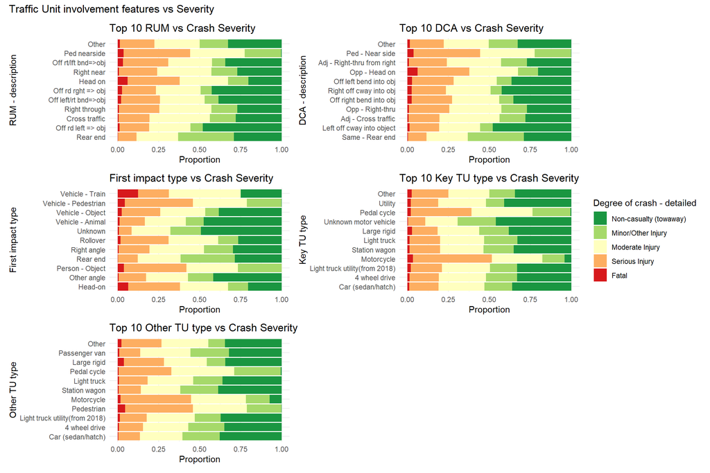

```r
# plots
# RUM vs target
p_rum <- ggplot(crash_data_cat %>%
         mutate(`RUM - description` = lump_top_n(`RUM - description`, n = 10)),
       aes(x = `RUM - description`, fill = `Degree of crash - detailed`)) +
  geom_bar(position = "fill") +
  labs(title = "Top 10 RUM vs Crash Severity",
       y = "Proportion") +
  theme_minimal() +
  scale_fill_brewer(palette = 'RdYlGn',direction = -1) +
  coord_flip()

# DCA vs target
p_dca <- ggplot(crash_data_cat %>%
         mutate(`DCA - description` = lump_top_n(`DCA - description`, n = 10)),
       aes(x = `DCA - description`, fill = `Degree of crash - detailed`)) +
  geom_bar(position = "fill") +
  labs(title = "Top 10 DCA vs Crash Severity",
       y = "Proportion") +
  theme_minimal() +
  scale_fill_brewer(palette = 'RdYlGn',direction = -1) +
  coord_flip()

# First impact type vs target
p_impact <- ggplot(crash_data_cat, aes(x = `First impact type`, fill = `Degree of crash - detailed`)) +
  geom_bar(position = "fill") +
  labs(title = "First impact type vs Crash Severity",
       y = "Proportion") +
  theme_minimal() +
  scale_fill_brewer(palette = 'RdYlGn',direction = -1) +
  coord_flip()

# Key TU type vs target
p_key_tu <- ggplot(crash_data_cat %>%
         mutate(`Key TU type` = lump_top_n(`Key TU type`, n = 10)),
       aes(x = `Key TU type`, fill = `Degree of crash - detailed`)) +
  geom_bar(position = "fill") +
  labs(title = "Top 10 Key TU type vs Crash Severity",
       y = "Proportion") +
  theme_minimal() +
  scale_fill_brewer(palette = 'RdYlGn',direction = -1) +
  coord_flip()

# Other TU type vs target
p_other_tu <- ggplot(crash_data_cat %>%
         mutate(`Other TU type` = lump_top_n(`Other TU type`, n = 10)),
       aes(x = `Other TU type`, fill = `Degree of crash - detailed`)) +
  geom_bar(position = "fill") +
  labs(title = "Top 10 Other TU type vs Crash Severity",
       y = "Proportion") +
  theme_minimal() +
  scale_fill_brewer(palette = 'RdYlGn',direction = -1) +
  coord_flip()

# plot matrix
tu_plots <- list(
  p_rum,
  p_dca,
  p_impact,
  p_key_tu,
  p_other_tu
)

p_tu_matrix <- wrap_plots(tu_plots, ncol = 2) +
  plot_layout(guides = "collect") +
  plot_annotation(title = "Traffic Unit involvement features vs Severity")

p_tu_matrix
```

## Evaluation Plan

We suggest five possible classification models, each with pros and cons, using different features. Our first model, **multinomial logistic regression**, acts as a interpretable measure with low variability, allowing us to evaluate findings with real-world applicability. We would use one-hot encoding for our categorical variables, including time of day, day of week, school zone activity, weather, and street and natural lighting. Time of day and day of week would be cyclically encoded using sine or cos to accurately reflect their circular nature. We would pool rare categories for Urbanisation, Street type, Type of location, Alignment, and Road surface/condition, then one-hot encode the variables. We would include speed limit and the nearest camera variables as numeric variables, first combining the camera variables into a product of the two distances, then applying a log1p transformation. An alternative to this would be using a binary feature to indicate whether the nearest camera is within a given radius (e.g., 0.5 km), although multicollinearity would still be a consideration. Numerical values would be standardised and classes weighted.

Secondly, **LDA** would be a fast, stable linear comparator, strong when class-conditional distributions are near-Gaussian with shared covariance. We would use the same features as above, although we would consider dimensionality reduction and covariance shrinkage to improve the model.

Next, a **kNN classifier** would work well as a non-parametric option, good at capturing local non-linearity. We would like to keep any features used low-noise, well-scaled, and keep dimensionality low. As such, we would use the same adjusted time/day features, the school zone feature, numeric speed, number of TUs, and one-hotted Urbanisation and road surface/condition features. These would be standardised, and hyperparameters like k and distance would be tuned with k-fold cross-validation.

Another non-parametric option is a **Support Vector Machine**, which is strong on complex boundaries, can capture non-linearity, and supports class weights. This would include KNN’s numeric features, along with dummy coding for road type variables and key interactions like Speed × Urbanisation, Hour × Lighting, Camera distance × Speed. We would use a Gaussian radial kernel, tuning C and gamma with k-fold cross-validation, with class weights.

Finally, we suggest a **random forest model**. This is an effective low-bias choice as it learns non-linearity and interactions automatically and is good for categorical data (a large proportion of our features). No scaling is necessary, and it offers feature importance scores, which would allow for simple real-world policy suggestions. We would use time/day as adjusted previously, school zone, all weather and environment variables, all road variables, all speed variables (ordered), and can use both camera variables (as random forest is robust to multicollinearity).

To evaluate the models, we would primarily use Macro-F1, Macro-AUPRC, Balanced Accuracy, MCC, QWK, and Ordinal-MAE, and secondarily use classwise Precision/Recall/F1, and ROC/AUC (reported, not primary). F1 is excellent for class-imbalanced data, making it an apt choice. We would set a recall target for serious and fatal crashes, (e.g., > 0.75), and optimise via threshold and cost on validation while also reporting precision.

## Appendix

#### References

1. New South Wales Government, 2025–26 NSW Budget: Regional NSW (Glossy). Sydney, Australia: NSW Treasury, 2025. [Online]. Available: https://www.budget.nsw.gov.au/2025-26/budget-papers/regional- . [Accessed: Sep. 6, 2025].
2. Transport for New South Wales, “NSW Crash Data,” Transport for NSW Open Data Hub and Developer Portal, Mar. 23, 2018. [Online]. Available: https://opendata.transport.nsw.gov.au/dataset/nsw-crash-data
3. Transport for New South Wales, “NSW Speed Cameras,” Transport for NSW Open Data Hub and Developer Portal, Sep. 15, 2020. [Online]. Available: https://opendata.transport.nsw.gov.au/dataset/nsw-speed-cameras . [Accessed: Aug. 21, 2023].
4. Transport New South Wales, “Classified Roads Schedule” Transport Asset Planning and Assurance, Feb. 2023. [Online]. Available: https://www.transport.nsw.gov.au/system/files/media/documents/2023/classified-roads-schedule.pdf. [Accessed: Sep. 15, 2025]

#### Missing Data & Data Dictionary

```r
# Function to check for missing values in the dataset
missing_summary <- function(df, dataset_name) {
  data.frame(
    dataset        = dataset_name,
    column         = names(df),
    missing_count  = colSums(is.na(df)),
    total_rows     = nrow(df),
    missing_percent = round(100 * colSums(is.na(df)) / nrow(df), 2)
  ) %>%
    filter(missing_count > 0) %>%        # keep only columns with missing values
    arrange(desc(missing_count))
}

crash_missing <- missing_summary(crash_data, "Crash Data")
# print(crash_missing)
kable(crash_missing,format="pipe")
```

Crash-level data (2019–2023): Data dictionary

|  | dataset | column | missing_count | total_rows | missing_percent |
| --- | --- | --- | --- | --- | --- |
| DCA supplement | Crash Data | DCA supplement | 66001 | 76197 | 86.62 |
| Route no. | Crash Data | Route no. | 28575 | 76197 | 37.50 |
| RouteCategory | Crash Data | RouteCategory | 28575 | 76197 | 37.50 |
| Other TU type | Crash Data | Other TU type | 23542 | 76197 | 30.90 |
| Speed limit | Crash Data | Speed limit | 24 | 76197 | 0.03 |

| Column Name | Example | Type |
| --- | --- | --- |
| Crash ID | 1215627 | numeric |
| Degree of crash - detailed | Fatal | ordered/factor |
| Year of crash | 2019 | numeric |
| Month of crash | November | ordered/factor |
| Day of week of crash | Friday | ordered/factor |
| Two-hour intervals | 14:00 - 15:59 | ordered/factor |
| Street type | WAY | character |
| Town | JINDABYNE | character |
| Route no. | 7626 | numeric |
| School zone location | No | character |
| School zone active | Not a school zone | character |
| Type of location | 2-way undivided | character |
| Latitude | -36.432489 | numeric |
| Longitude | 148.608746 | numeric |
| LGA | Snowy Monaro Regional | character |
| Urbanisation | Country non-urban | character |
| Conurbation 1 | Rest of NSW - Rural | character |
| Alignment | Straight | character |
| Street lighting | Nil | character |
| Road surface | Sealed | character |
| Surface condition | Dry | character |
| Weather | Fine | ordered/factor |
| Natural lighting | Daylight | ordered/factor |
| Signals operation | Nil | character |
| Other traffic control | No traffic controls | character |
| Speed limit | 100 | numeric |
| RUM - code | 32 | numeric |
| RUM - description | Right rear | character |
| DCA - code | 303 | numeric |
| DCA - description | Same - Rear right | character |
| DCA supplement | Left | character |
| First impact type | Rear end | character |
| Key TU type | Motorcycle | character |
| Other TU type | 4 wheel drive | character |
| No. of traffic units involved | 2 | numeric |
| No. killed | 1 | numeric |
| No. seriously injured | 0 | numeric |
| No. moderately injured | 1 | numeric |
| No. minor-other injured | 0 | numeric |
| nearest_fixed_km | 109.540961623414 | numeric |
| nearest_redlight_km | 156.094723867817 | numeric |
| RouteCategory | UR | ordered/factor |